# Human Activity Recognition

Eli Duenisch

December 27, 2015

## Background

Using devices such as Jawbone Up, Nike FuelBand, and Fitbit it is now possible to collect a large amount of data about personal activity relatively inexpensively. These type of devices are part of the quantified self movement – a group of enthusiasts who take measurements about themselves regularly to improve their health, to find patterns in their behavior, or because they are tech geeks. One thing that people regularly do is quantify how much of a particular activity they do, but they rarely quantify how well they do it. In this project, your goal will be to use data from accelerometers on the belt, forearm, arm, and dumbell of 6 participants. They were asked to perform barbell lifts correctly and incorrectly in 5 different ways. More information is available from the website here http://groupware.les.inf.puc-rio.br/har (see the section on the Weight Lifting Exercise Dataset).

## The Data

The training data set is available for download here: [https://d396qusza40orc.cloudfront.net/predmachlearn/pml-training.csv]  
The test data set is available for download here: [https://d396qusza40orc.cloudfront.net/predmachlearn/pml-testing.csv]

## The Goal

Our goal is to predict classes of human activity given data of different kind measured by fitness devices.

The five classes of activity are: A exactly according to the specification B throwing the elbows to the front C lifting the dumbbell only halfway D lowering the dumbbell only halfway E throwing the hips to the front

The variables that contains our data to use our prediction model will be listed below after data preprocessing has been applied.

## Preprocessing Data

First we need to obtain the data, handle missing values, remove variables that contain too many NAs or which have a variability close to zero.

```r
# loading libraries
library(lattice)
library(ggplot2)
library(caret)
library(randomForest)
# downloading the data
downloadUrl <-"https://d396qusza40orc.cloudfront.net/predmachlearn/"
trainingDataCsvFile <- "pml-training.csv"
testingDataCsvFile <- "pml-testing.csv"
if (!file.exists(trainingDataCsvFile)) {
  download.file(paste(downloadUrl,trainingDataCsvFile,sep=""),destfile=trainingDataCsvFile)
}
if (!file.exists(testingDataCsvFile)) {
  download.file(paste(downloadUrl,testingDataCsvFile,sep=""),destfile=testingDataCsvFile)
}

# handling missing values
naStrings <- c("", "NA", "#DIV/0!")
trainingData <- read.csv(trainingDataCsvFile, na.strings=naStrings, row.names=1)
testingData <- read.csv(testingDataCsvFile, na.strings=naStrings, row.names=1)

# removing the first 6 columns which contain no relevant information for our analysis
trainingData <- trainingData[,-c(1:6)]
testingData <- testingData[,-c(1:6)]

# removing variables that conatin more than 25 percent NAs
numberOfNAvaluesTreshold <- 0.25*dim(trainingData)[1]
belowTresholdVariables <- apply(trainingData, 2, function(x) (sum(is.na(x))<numberOfNAvaluesTreshold))
trainingData <- trainingData[,belowTresholdVariables]
testingData <- testingData[,belowTresholdVariables]

# removing variables that have a near zero variability as they cannot contribute to our prediction model
nearZeroVarianceVariables <- nearZeroVar(trainingData)
if(length(nearZeroVarianceVariables)>0){
  trainingData <- trainingData[-nearZeroVarianceVariables]
  testingData <- testingData[-nearZeroVarianceVariables]
}

# show the names of the remaining variables
print(names(trainingData))
```

```
##  [1] "roll_belt"            "pitch_belt"           "yaw_belt"
##  [4] "total_accel_belt"     "gyros_belt_x"         "gyros_belt_y"
##  [7] "gyros_belt_z"         "accel_belt_x"         "accel_belt_y"
## [10] "accel_belt_z"         "magnet_belt_x"        "magnet_belt_y"
## [13] "magnet_belt_z"        "roll_arm"             "pitch_arm"
## [16] "yaw_arm"              "total_accel_arm"      "gyros_arm_x"
## [19] "gyros_arm_y"          "gyros_arm_z"          "accel_arm_x"
## [22] "accel_arm_y"          "accel_arm_z"          "magnet_arm_x"
## [25] "magnet_arm_y"         "magnet_arm_z"         "roll_dumbbell"
## [28] "pitch_dumbbell"       "yaw_dumbbell"         "total_accel_dumbbell"
## [31] "gyros_dumbbell_x"     "gyros_dumbbell_y"     "gyros_dumbbell_z"
## [34] "accel_dumbbell_x"     "accel_dumbbell_y"     "accel_dumbbell_z"
## [37] "magnet_dumbbell_x"    "magnet_dumbbell_y"    "magnet_dumbbell_z"
## [40] "roll_forearm"         "pitch_forearm"        "yaw_forearm"
## [43] "total_accel_forearm"  "gyros_forearm_x"      "gyros_forearm_y"
## [46] "gyros_forearm_z"      "accel_forearm_x"      "accel_forearm_y"
## [49] "accel_forearm_z"      "magnet_forearm_x"     "magnet_forearm_y"
## [52] "magnet_forearm_z"     "classe"
```

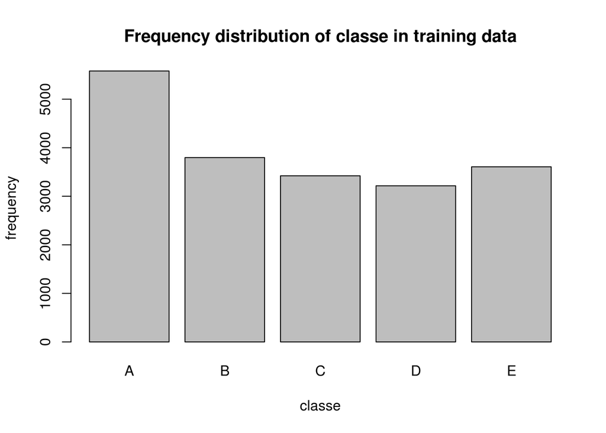

```r
# plot the frequency distribution of the classes of activity
plot(trainingData$classe, main="Frequency distribution of classe in training data", xlab="classe", ylab="frequency")
```

Now we divide the training data into a training and a validation set.

```r
# set seed for reproducible random number generation
set.seed(12345)
# get data partitions
partition <- createDataPartition(y=trainingData$classe, p=0.6,list=FALSE)
trainingPartition <- trainingData[partition,]
validationPartition  <- trainingData[-partition,]
```

## Fit a Model using a Random Forest Algorithm

We are using the RF implementation from the caret package and a 5-fold cross validation.

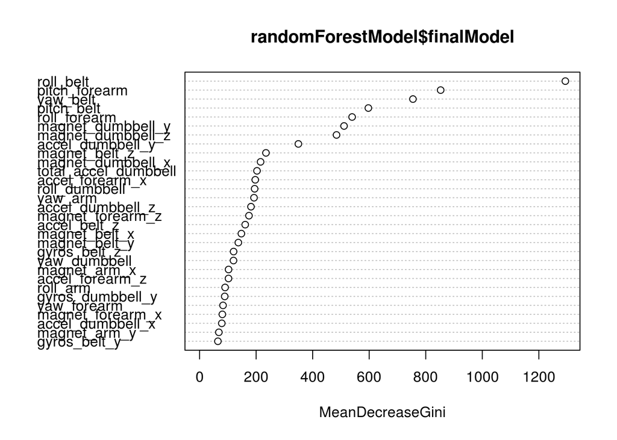

```r
# training the model
randomForestModel <- train(classe ~ .,data=trainingPartition,method="rf",ntree=10,trControl=trainControl(method = "cv", number = 5))
# plot the variables
varImpPlot(randomForestModel$finalModel)
```

The importance of the variables used in the final model of the RF.

## RF errors and Cross Validation

Check the results of the model:

```r
# check model fit on training data
randomForestModel_PredictionTraining <- predict(randomForestModel$finalModel,newdata=trainingPartition)
# get confusion matrix
cm <- confusionMatrix(randomForestModel_PredictionTraining,trainingPartition$classe)
print(cm)
```

```
## Confusion Matrix and Statistics
##
##           Reference
## Prediction    A    B    C    D    E
##          A 3348    2    0    0    0
##          B    0 2277    0    0    0
##          C    0    0 2051    2    1
##          D    0    0    3 1927    0
##          E    0    0    0    1 2164
##
## Overall Statistics
##
##                Accuracy : 0.9992
##                  95% CI : (0.9985, 0.9997)
##     No Information Rate : 0.2843
##     P-Value [Acc > NIR] : < 2.2e-16
##
##                   Kappa : 0.999
##  Mcnemar's Test P-Value : NA
##
## Statistics by Class:
##
##                      Class: A Class: B Class: C Class: D Class: E
## Sensitivity            1.0000   0.9991   0.9985   0.9984   0.9995
## Specificity            0.9998   1.0000   0.9997   0.9997   0.9999
## Pos Pred Value         0.9994   1.0000   0.9985   0.9984   0.9995
## Neg Pred Value         1.0000   0.9998   0.9997   0.9997   0.9999
## Prevalence             0.2843   0.1935   0.1744   0.1639   0.1838
## Detection Rate         0.2843   0.1934   0.1742   0.1636   0.1838
## Detection Prevalence   0.2845   0.1934   0.1744   0.1639   0.1838
## Balanced Accuracy      0.9999   0.9996   0.9991   0.9991   0.9997
```

Now check the results when the model is applied to the validation data set:

```r
# apply model on validation data set
randomForestModel_PredictionValidation <- predict(randomForestModel$finalModel,newdata=validationPartition)
# get confusion matrix
cm <- confusionMatrix(randomForestModel_PredictionValidation,validationPartition$classe)
print(cm)
```

```
## Confusion Matrix and Statistics
##
##           Reference
## Prediction    A    B    C    D    E
##          A 2224   15    0    0    0
##          B    5 1484   18    0    3
##          C    2   16 1336   23    5
##          D    0    2   14 1259    7
##          E    1    1    0    4 1427
##
## Overall Statistics
##
##                Accuracy : 0.9852
##                  95% CI : (0.9823, 0.9878)
##     No Information Rate : 0.2845
##     P-Value [Acc > NIR] : < 2.2e-16
##
##                   Kappa : 0.9813
##  Mcnemar's Test P-Value : NA
##
## Statistics by Class:
##
##                      Class: A Class: B Class: C Class: D Class: E
## Sensitivity            0.9964   0.9776   0.9766   0.9790   0.9896
## Specificity            0.9973   0.9959   0.9929   0.9965   0.9991
## Pos Pred Value         0.9933   0.9828   0.9667   0.9821   0.9958
## Neg Pred Value         0.9986   0.9946   0.9950   0.9959   0.9977
## Prevalence             0.2845   0.1935   0.1744   0.1639   0.1838
## Detection Rate         0.2835   0.1891   0.1703   0.1605   0.1819
## Detection Prevalence   0.2854   0.1925   0.1761   0.1634   0.1826
## Balanced Accuracy      0.9969   0.9867   0.9848   0.9877   0.9943
```

## Prediction using the RF model

Finally we apply our model on the testing data set to predict the activity classes:

```r
# apply model on testing data set
randomForestModel_PredictionTesting <- predict(randomForestModel$finalModel,newdata=testingData)
# show predictions
print(randomForestModel_PredictionTesting)
```

```
##  1  2  3  4  5  6  7  8  9 10 11 12 13 14 15 16 17 18 19 20
##  B  A  B  A  A  E  D  B  A  A  B  C  B  A  E  E  A  B  B  B
## Levels: A B C D E
```

## Conclusion

Using RF angorithm with the given parameters performed well enough to predict the classes in the testing data set sufficient for passing the tasks given by Coursera.